# Lesson 19

Timothy Luna

9/15/2019

# 3C-L1 Extrinsic Camera Parameters

## Intro

In order to do real depth reconstruction we have to understand the geometry of the imaging system.

Let’s revisit the idea of perspective projection and how we changed coordinates to homogeneous coordinates to change operations to linear operations.

$(X,Y,Z) \rightarrow -\frac{d}{Z}(X,Y,Z)$

Division by Z was non-linear!

$(x,y,z) \rightarrow[x,y,z,1]$

$(x,y,z,w) \rightarrow [\frac{x}{w},\frac{y}{w},\frac{z}{w},q]$

Now perspective projection is a linear algebra operation (go back and look at that lecture, I’m not rewriting this.)

The origin on the coordinate system (center of projection) is centered in the camera scene, with Z projecting outward toward the world.

What about the *world* coordinate system?

Time for some transformation matrices!

## Geometric Camera Calibration

In order for information from the camera to tell us things about the world we need to know the relationship between the two coordinate systems.

Calibration is composed of two transformations. The first (extrinsic parameters or camera pose) goes from some arbitrary world coordinate system to the camera 3D frame. The second goes from the 3D camera system to the 2D image plane via projection (intrinsic parameters.)

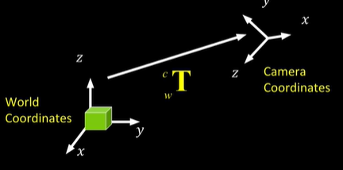

The transformation matrix $_W^C T$ goes from the world to the camera, thus the super and subscripts on the left side of T.

## Quiz: Degrees of Freedom

For rigid body transformations there are *six* degrees of freedom. Why?

## Rigid Body Transformations

Three translations and three rotations. A *rigid* body is a collection of points whose orientation *with respect to one another* cannot change.

Take one point in the box and it has an x, y, and z location. That’s three degrees of freedom. The whole body can also rotate around three axes. That’s three more degrees of freedom.

## Notation

The superscript in these equations references the coordinate frame of that vector.

For instance ${}^A P$ is the coordinates of P in frame A and ${}^B P$ is the coordinates of P in frame B.

${}^A P = \begin{bmatrix} {}^A x \\ {}^A y \\ {}^A z \end{bmatrix} \leftrightarrow \vec{OP} = ({}^A x \cdot \vec{i_A}) + ({}^A y \cdot \vec{j_A}) + ({}^A z \cdot \vec{k_A})$$

The location of P in the A coordinate frame can be the location of x, y, and z in A, or the vector from the origin of P multiplied by the unit vectors.

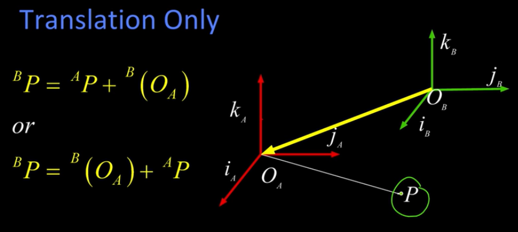

Suppose we want to express point P in terms of frame B, how would we write that?

$${}^B P = {}^A P + {}^B(O_A)$$

The above equation says the coordinates for point P are equal to the coordinates in frame A *plus* the relative position of the A frame origin in the B coordinate system.

$${}^B P = {}^B(O_A) + {}^A P$$

Thankfully we can use homogeneous coordinates and translation is *yet again* simplified to matrix multiplication.

$$\begin{bmatrix} {}^B P \\ 1\end{bmatrix} = \begin{bmatrix} I {}^B O_A \\ 0^T 1\end{bmatrix}\begin{bmatrix} {}^A P \\ 1\end{bmatrix}$$

Yay for math.

Why should we care about this? Because it makes math easy!

Remember that translation is commutative.

## Rotation

Rotation is harder. A vector can be expressed as some components in one frame times the other components in the other frame. They are the same vector. We need to know how much to multiply the basis vectors.

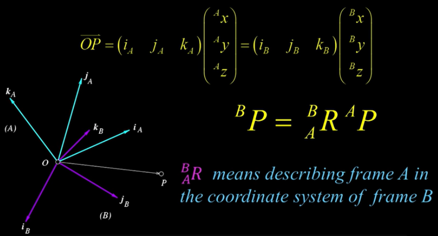

Given a point described in A there will be a rotation operator R which describes a frame (subscript) in terms of another frame (superscript).

## What does R Look Like?

Ugly. The first column is the i vector in A in terms of B. The second is the j and the third is k. This entire matrix falls out from geometry. Derive this if you feel like it.

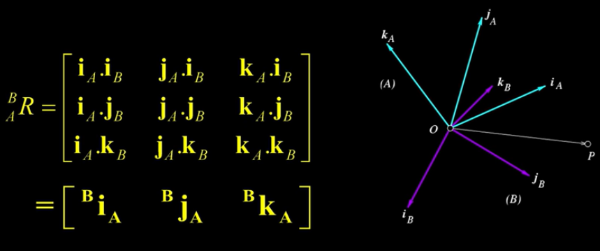

This is an orthogonal matrix because all the rows and columns are unit vectors perpindicular to one another. The inverse is equal to the transpose. The inverse to RAB has to be RBA.

## Rotation About Z Axis Example

Here there are two frames. The rotation from A to B is just a rotation around the Z axis. This is just a planar rotation

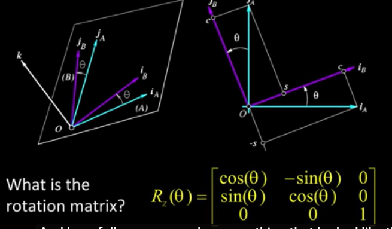

The cos/sin matrix is just the projections on the x and y axes from one from to another.

When you’re transforming the order of the operations *matters*. A very common way to get an arbitrary rotation is *Euler angles* which is a rotation about Z, the new X axis, and then the new Y axis.

Basically there are three matrices for rotation and the order matters.

[figure not shown]

Pre or post multiplication matters! Are the angles positive or negative?

## Rotation in Homogeneous Coordinates

Is there an easier way? Homogeneous coordinates! Yay! Assume you HAVE a rotation matrix. Instead of the identity matrix we have R coupled with a zero. This makes rotation a matrix multiplication.

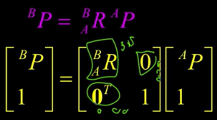

**ROTATION IS NOT COMMUTATIVE**

## Rigid Transformation

A total rigid transformation first must be rotated and *then* must be offset by a translation.

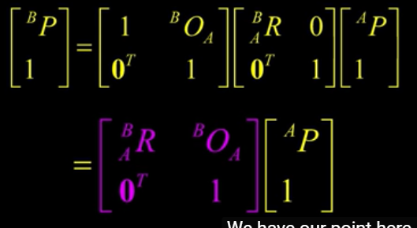

This takes care of the translation and the rotation alla t the same time!

This can be rewritten becase the translation is invertible! The invertibility of homogenous transformations is awesome.

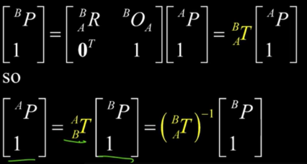

## Translation and Rotation

In Non-homogeneous coordinates:

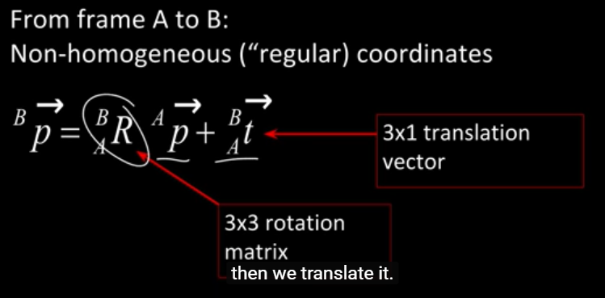

In homogeneous coordinates:

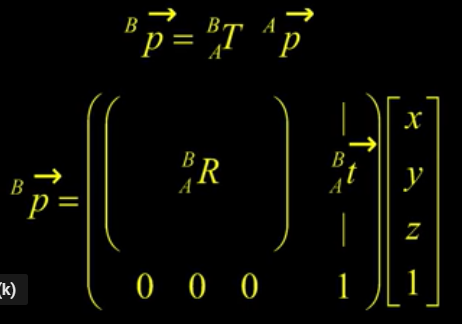

Homogeneity allows for the whole expression to be a single matrix! Whoooo!

This ugly equation lets us go from a point in the world to a point in the camera frame, or vice versa.

The four by four matrix in the homogeneous equation is the *extrinsic* parameter matrix.

## Quiz: Extrinsic Parameter Matrix

How many degrees of freedom are there in the 3x4 parameter matrix?

Still six! Three angular rotations and three linear translations.

## End

We’ll revisit this *whole thing* when we talk about mapping from a world point to a point in the image plane, but first let’s talk about going from a point in the 3D camera scene to the 2D image scene.